# Machine Learning for Human Learners

Transposing the problem — clustering the 42 *items* by their pairwise response correlations across people ($d_{ij} = 1 - r_{ij}$) — tests whether items covary according to their designed subscales:

Compute the correlation between each pair of questionnaire items, then join the most similar groups. Subtracting correlation from one turns stronger similarity into a smaller distance.

```python
from scipy.cluster.hierarchy import dendrogram, linkage
from scipy.spatial.distance import squareform

items = dass_items()
# Correlate questionnaire items across respondents, then turn similarity into distance.
item_correlations = dass[items.item].corr().to_numpy()
link = linkage(squareform(1 - item_correlations, checks=False), method="complete")

scale_color = {"depression": C["blue"], "anxiety": C["orange"], "stress": C["green"]}
```

**Show the figure code**

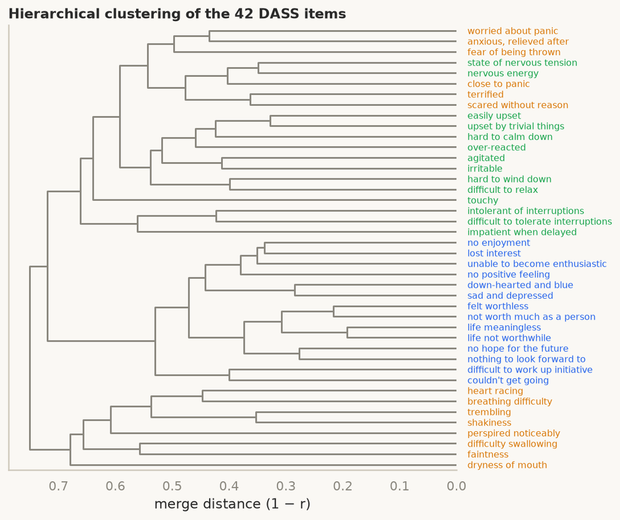

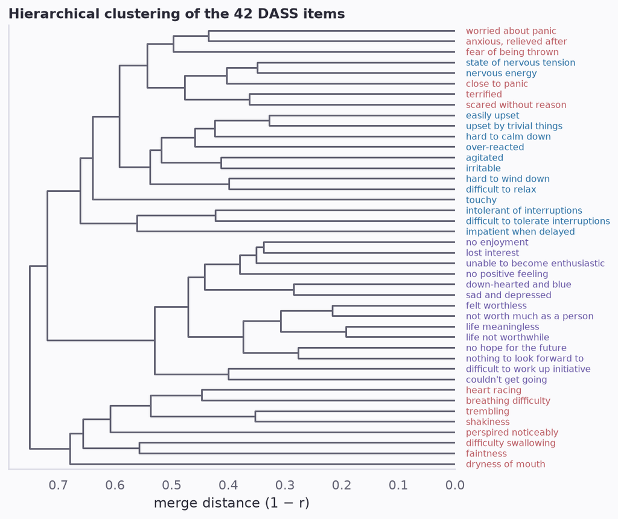

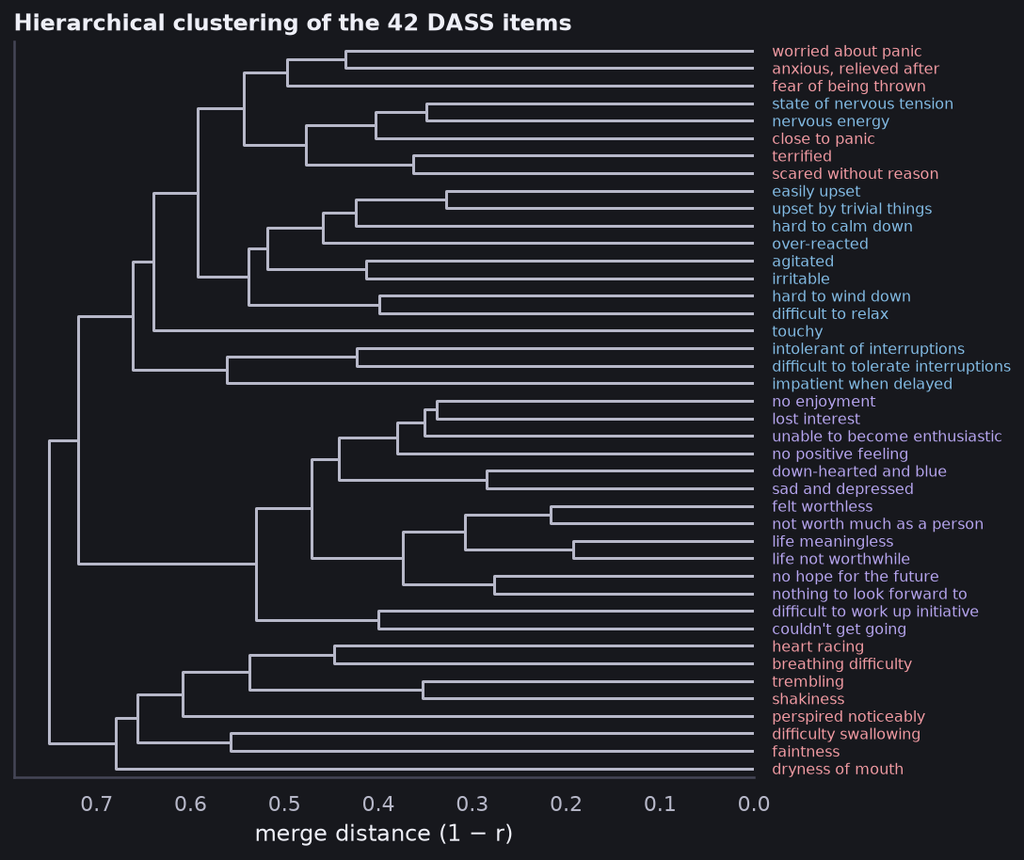

```python
# Draw the results computed above; this cell does not fit the model.
fig, ax = plt.subplots(figsize=(7, 7))
dendrogram(link, labels=items.text.tolist(), orientation="left", color_threshold=0,
           above_threshold_color=C["muted"], ax=ax)
for lbl in ax.get_ymajorticklabels():
    lbl.set_color(scale_color[items.set_index("text").scale[lbl.get_text()]])
    lbl.set_fontsize(8)
ax.set(xlabel="merge distance (1 − r)", title="Hierarchical clustering of the 42 DASS items")
ax.grid(False)
plt.show()
```

Without access to the ground-truth (human-labeled) scoring key (colors identify depression, anxiety, and stress), complete-linkage clustering groups cognitive-affective depression items (*“no positive feeling”*, *“life meaningless”*), autonomic anxiety items (*“trembling”*, *“heart racing”*, *“dryness of mouth”*), and tension/irritability stress items (*“hard to wind down”*, *“touchy”*) into distinct, semantically coherent subtrees. These labels describe the questionnaire design; they are not diagnostic ground truth.

**Music Therapy: Affective Clusters**

In music cognition and music therapy, researchers ask how musical excerpts organize across emotional and regulatory states (such as soothing/anxiolytic vs. activating/energizing). [Cowen et al. (2020)](https://doi.org/10.1073/pnas.1910704117) collected ratings of $1,841$ musical excerpts across 28 affective dimensions from United States and Chinese listeners (`load_music_emotions`). Below, we pass the 13 core affective dimensions to K-means and hierarchical clustering:

```python
from ml4hl.data import load_music_emotions

music_emotions = load_music_emotions()
emotion_ratings, core_emotions = music_emotions["df"], music_emotions["core13"]
# Standardization prevents a more variable rating scale from dominating distances.
standardized_emotions = StandardScaler().fit_transform(emotion_ratings[core_emotions])
```

Group excerpts by their standardized ratings, then summarize selected emotional dimensions within each cluster.

```python
music_clusters = KMeans(4, n_init=10, random_state=0).fit(standardized_emotions)
show_dims = ["calm/relaxing/serene", "dreamy", "compassionate/sympathetic",
             "joyful/cheerful", "energizing/pump-up", "anxious/tense", "sad/depressing"]
short_labels = [d.split("/")[0] for d in show_dims]
emo_profiles = emotion_ratings[show_dims].groupby(music_clusters.labels_).mean()
```

For the second panel, compare the emotion dimensions themselves. Dimensions with correlated ratings across excerpts are joined earlier in the tree.

```python
R_emo = emotion_ratings[core_emotions].corr().to_numpy()
link_emo = linkage(squareform(np.maximum(0, 1 - R_emo), checks=False), method="complete")
```

**Show the figure code**

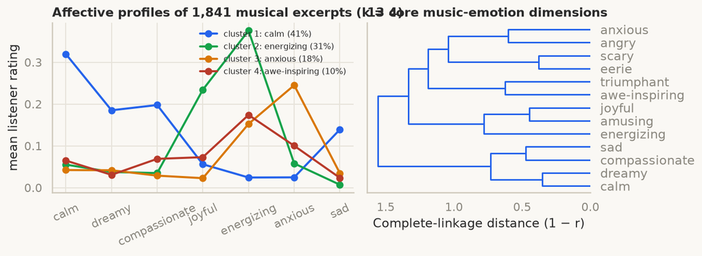

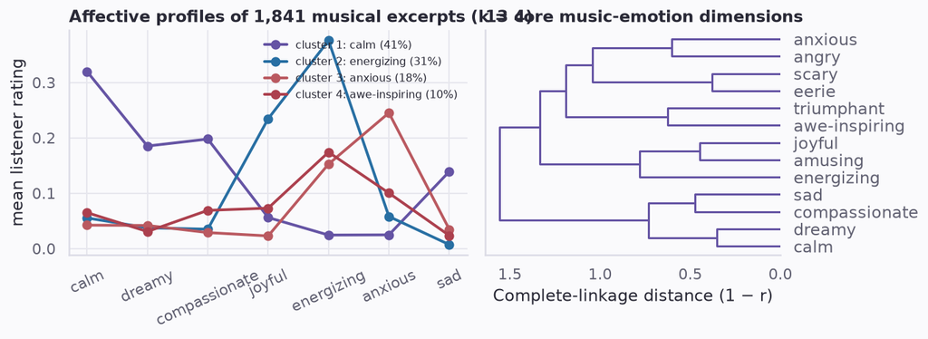

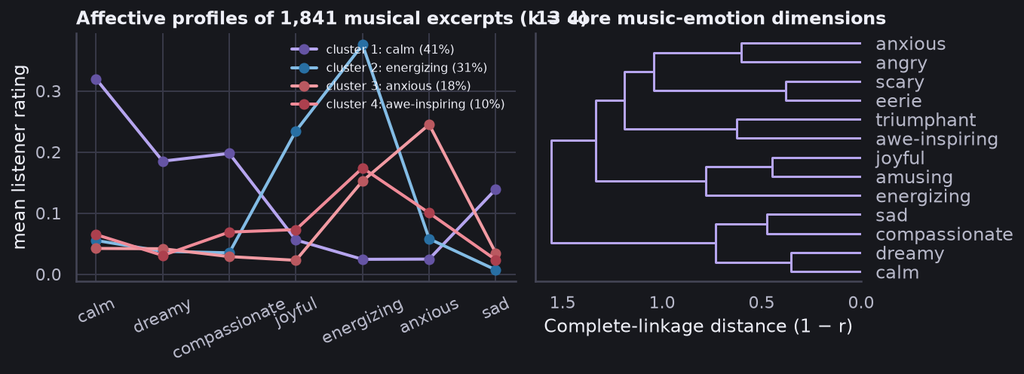

```python
# Draw the results computed above; this cell does not fit the model.
fig, axes = plt.subplots(1, 2, figsize=(9.6, 3.6), gridspec_kw={"width_ratios": [1.35, 1]})
for (cl, row), col in zip(emo_profiles.iterrows(), [C["blue"], C["green"], C["orange"], C["red"]]):
    top_dim = emotion_ratings.loc[music_clusters.labels_ == cl, "top_emotion"].mode().iloc[0].split("/")[0]
    axes[0].plot(short_labels, row.values, "o-", color=col, lw=2,
                 label=f"cluster {cl + 1}: {top_dim} ({(music_clusters.labels_ == cl).mean():.0%})")
axes[0].set(ylabel="mean listener rating", title="Affective profiles of 1,841 musical excerpts (k = 4)")
axes[0].tick_params(axis="x", rotation=25)
axes[0].legend(frameon=False, fontsize=8)

dendrogram(link_emo, labels=[c.split("/")[0] for c in core_emotions], orientation="left",
           color_threshold=0, above_threshold_color=C["blue"], ax=axes[1])
axes[1].set(xlabel="Complete-linkage distance (1 − r)", title="13 core music-emotion dimensions")
axes[1].grid(False)
plt.tight_layout()
```

**Anthropology: Kinds of Home**

Returning to the Dollar Street household embeddings (`photo_embeddings`), we test whether unsupervised K-means ($k = 8$) groups photographs by object category (bed, stove, front door) or by socioeconomic context:

```python
from sklearn.metrics import adjusted_rand_score

# Cluster image features only; household income is reserved for interpretation.
home_clusters = KMeans(8, n_init=10, random_state=0).fit(photo_embeddings)
photo_metadata["cluster"] = home_clusters.labels_
print(f"agreement with photo topics (adjusted Rand index, 1.0 = identical): {adjusted_rand_score(photo_metadata.topic, home_clusters.labels_):.2f}")
```

```
agreement with photo topics (adjusted Rand index, 1.0 = identical): 0.45
```

Summarize each cluster by its most common photo topic and median household income. These summaries describe the groups; income was not supplied to the clustering algorithm.

```python
summary = (photo_metadata.groupby("cluster")
               .agg(photos=("id", "size"), top_topic=("topic", lambda s: s.value_counts().index[0]),
                    share=("topic", lambda s: s.value_counts(normalize=True).iloc[0]),
                    median_income=("income", "median"))
               .sort_values("median_income"))
summary.style.format({"share": "{:.0%}", "median_income": "${:,.0f}"})
```

[output not shown]

**Show the figure code**

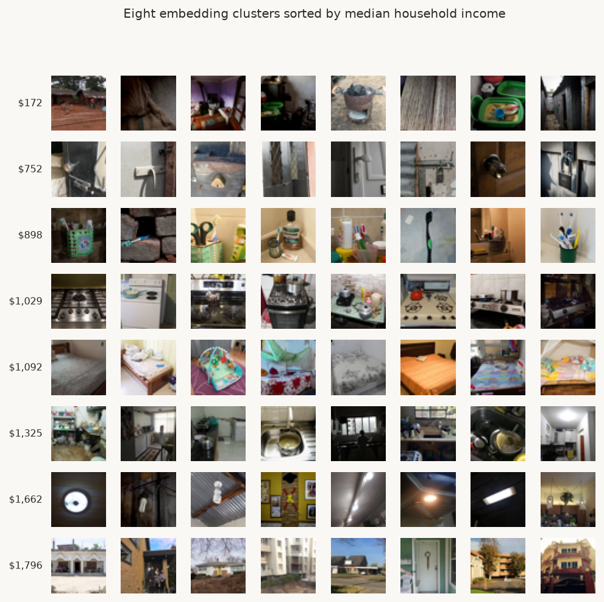

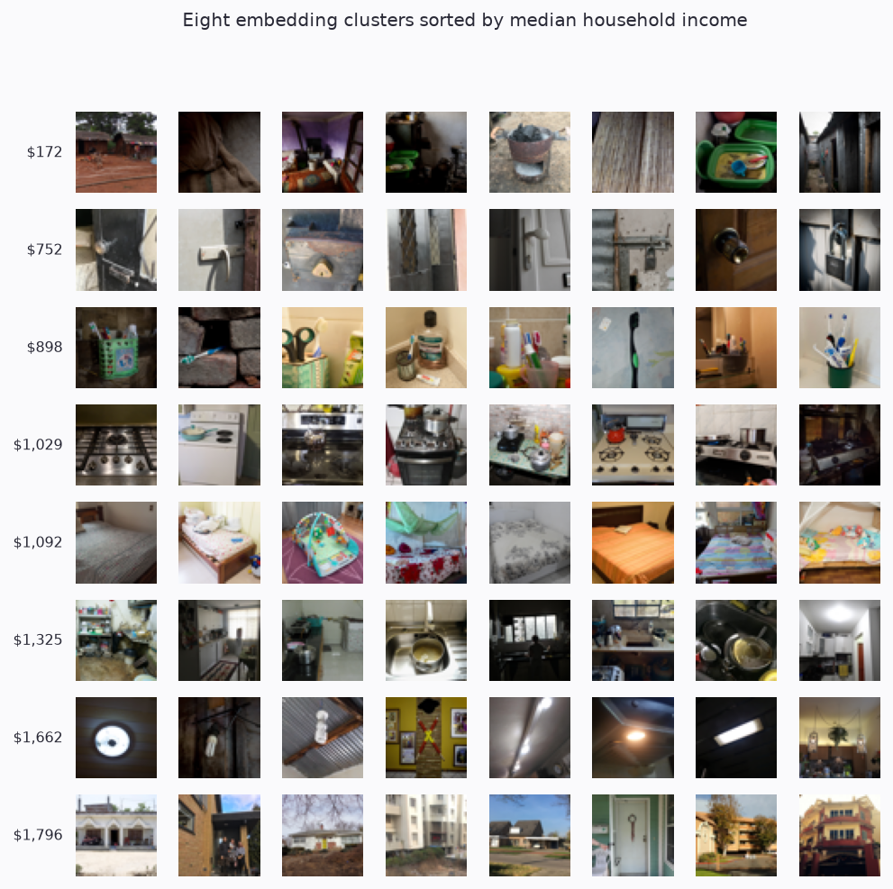

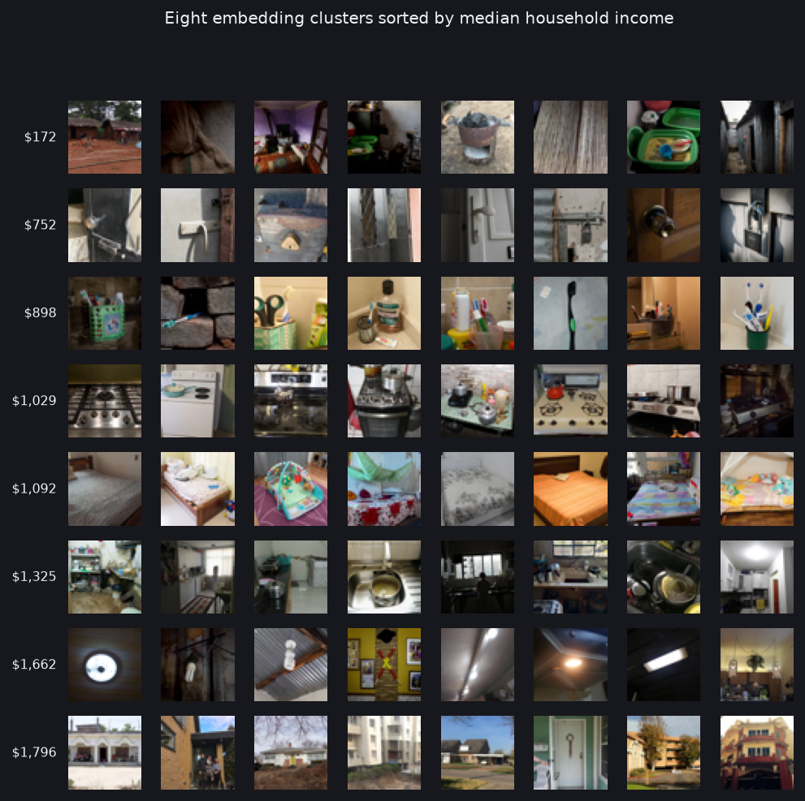

```python
# Select and label observations for this figure.

fig, axes = plt.subplots(len(summary), 8, figsize=(8, 0.95 * len(summary)))
for r, (cl, row) in enumerate(summary.iterrows()):
    members = np.where(photo_metadata.cluster == cl)[0]
    shown = rng.choice(members, min(8, len(members)), replace=False)
    for c in range(8):
        ax = axes[r, c]; ax.set_axis_off()
        if c < len(shown):
            ax.imshow(photo_thumbnails[shown[c]])
    axes[r, 0].text(-8, 24, f"${row.median_income:,.0f}", ha="right", va="center", fontsize=8)
fig.suptitle("Eight embedding clusters sorted by median household income", fontsize=10)
plt.show()
```

Compare the topic agreement statistic and thumbnails above. Any association between clusters and income is descriptive: photographed object, region, image composition, and material conditions may all contribute. These embeddings and clusters do not isolate a causal effect of socioeconomic conditions.

**Going faster**

For large tables, `MiniBatchKMeans` moves the group centers using small, randomly selected batches of observations instead of revisiting the entire table on every update. Each update therefore does less work, trading some precision for speed; on supported GPU runtimes, `cuml.accel` can also distribute the calculations across many processors.

# 5 Dimensionality Reduction: Represent Data with Fewer Coordinates

Empirical datasets routinely span dozens to hundreds of measurements per observation: 42 questionnaire items, 28 affective ratings, 101 acoustic features, or 768 embedding coordinates. **Dimensionality reduction** maps high-dimensional observations into a low-dimensional subspace while preserving as much variance or neighborhood structure as possible — enabling visualization, denoising, and latent-factor discovery.

## 5.1 Deep Cut Sneak Peek: An Autoencoder Squeezes, Then Rebuilds

An **autoencoder** is a neural network trained to reconstruct its own input after passing information through a narrow intermediate layer (**bottleneck**) containing far fewer numbers than the original input. Compressing a 64-pixel image into a 3-number bottleneck encourages a compact representation useful for reconstruction, without guaranteeing recovery of the underlying generative factors.

**Show the interactive figure code**

```python
show("autoencoder")
```

Each synthetic image in Figure 12 is a 2D Gaussian spot that varies in horizontal position, vertical position, and radius. Press **train**: the reconstructions in the bottom row rapidly converge toward the inputs, and the 2D latent scatter on the right organizes smoothly by horizontal position (color). Drag the latent-code sliders to decode new synthetic images directly from the bottleneck coordinates. Reducing the bottleneck width to $1$ restricts reconstruction to a single curve, while widening it to $16$ lowers reconstruction error at the expense of a less compact code.

Because the target output is the input itself ($y = x$), an autoencoder is a canonical example of **self-supervised learning**. Below, we run the same architecture on $8 \times 8$ handwritten digit images:

**Show the interactive figure code**

```python
from ml4hl.samples import digits_images

show("autoencoder", data=digits_images(n=300), bottleneck=4)
```

## 5.2 Projections: Principal Component Analysis (PCA) and Random Directions

A linear **projection** reduces dimensionality by taking the dot product of each point with a set of basis directions (recording each point’s orthogonal shadow onto a line or plane).

**Show the interactive figure code**

```python
show("projection")
```

Drag the projection axis in Figure 13 to rotate the projection direction. Each point projects onto its orthogonal shadow along the line, and the right-hand curve plots the fraction of total variance retained at every angle. For centered data, the direction that maximizes retained variance (and equivalently minimizes the sum of squared perpendicular reconstruction errors) is the **first principal component** (PC1). Subsequent principal components maximize variance subject to being mutually orthogonal. That orthogonal variance-maximizing basis defines **principal component analysis** (PCA).

Switch to the **random projection** tab. The Johnson–Lindenstrauss lemma gives probabilistic distance-preservation guarantees for a finite set of points when the target dimension is sufficiently large relative to the logarithm of the number of points and the desired error tolerance. Random projection directions need not be orthogonal. The widget illustrates empirical distance correlation; this is weaker than checking the theorem’s bound for every pair.

To inspect how keeping $k$ principal components reconstructs individual multi-feature profiles and how the eigenvalue **scree plot** distributes total variance across components, explore the `pca_reconstruct` widget below on the 13 core music-emotion dimensions:

**Show the interactive figure code**

```python
show("pca_reconstruct", data=dict(
    X=StandardScaler().fit_transform(emotion_ratings[core_emotions].sample(120, random_state=7).to_numpy()),
    feature_names=[c.split("/")[0] for c in core_emotions],
))
```

**Takeaway #7**

High-dimensional measurements often lie near a lower-dimensional subspace. Dimensionality reduction isolates the directions that capture the dominant variance of the higher-dimensional space.

## 5.3 Applied Examples

**Psychology: Rediscovering the Scales**

The [DASS-42](https://openpsychometrics.org/_rawdata/) contains 42 items designed around three clinical scales. Fitting PCA to the standardized $42$-item response matrix reveals how variance is distributed across orthogonal axes:

Standardize the questionnaire items and fit principal component analysis. The printed percentage reports how much of this sample’s total variation lies along the first component.

```python
from sklearn.decomposition import PCA, FactorAnalysis

standardized_items = StandardScaler().fit_transform(dass[items.item])
# PCA finds new axes ordered by how much variation they retain.
symptom_pca = PCA().fit(standardized_items)

print(f"PC1 explains {symptom_pca.explained_variance_ratio_[0]:.0%} of total variance across the 42 items")
```

```
PC1 explains 45% of total variance across the 42 items
```

**Show the figure code**

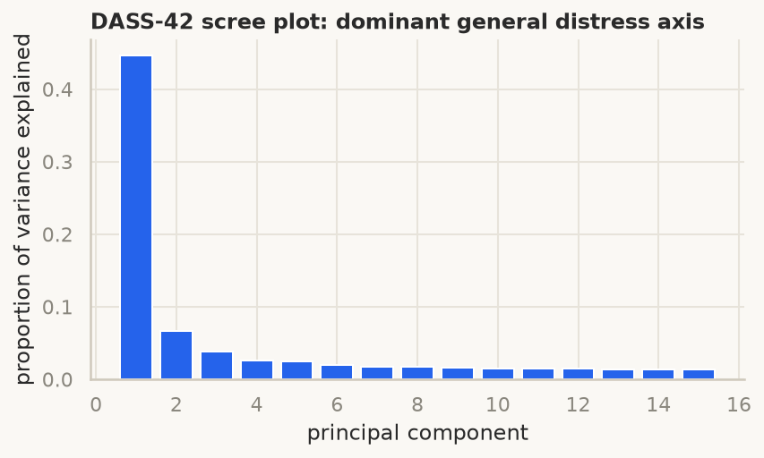

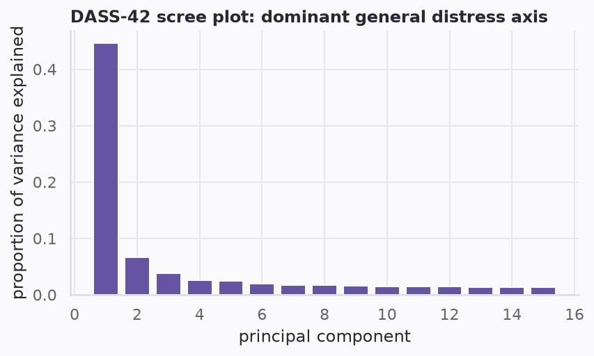

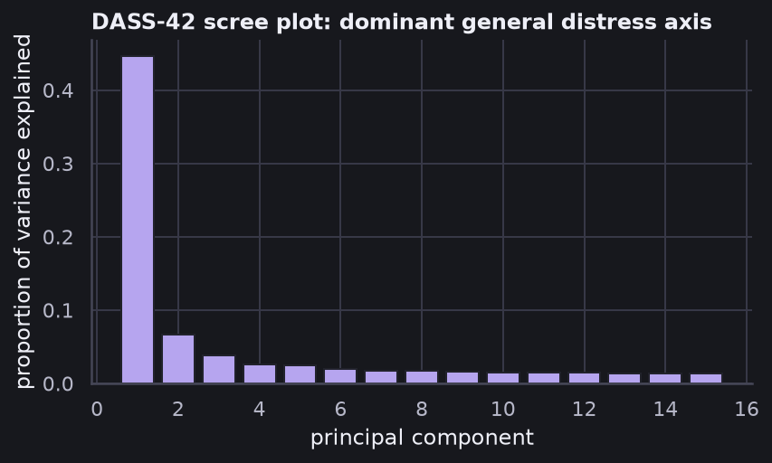

```python
# Draw the results computed above; this cell does not fit the model.
fig, ax = plt.subplots(figsize=(6.5, 3.4))
ax.bar(range(1, 16), symptom_pca.explained_variance_ratio_[:15], color=C["blue"])
ax.set(xlabel="principal component", ylabel="proportion of variance explained",
       title="DASS-42 scree plot: dominant general distress axis")
plt.show()
```

The printed value reports the variance explained by PC1 for this sample. PCA does not require all loadings to be positive, and component signs are arbitrary. Factor analysis instead models shared covariance and feature-specific noise. Varimax rotates the fitted factors toward a simpler loading pattern; it does not guarantee recovery of the intended questionnaire scales.

Fit three factors and inspect the strength of each item’s relationship to them. Compare each item’s strongest factor with the questionnaire’s designed scoring categories.

```python
symptom_factors = FactorAnalysis(n_components=3, rotation="varimax", random_state=0).fit(standardized_items)
# A loading records how strongly a questionnaire item relates to each fitted factor.
loadings = pd.DataFrame(symptom_factors.components_.T, index=items.text, columns=["factor 1", "factor 2", "factor 3"])
order_items = items.sort_values("scale").text

match = adjusted_rand_score(items.scale, loadings.abs().to_numpy().argmax(axis=1))
print(f"agreement between dominant factor loading and designed DASS scale (adjusted Rand): {match:.2f}")
```

```
agreement between dominant factor loading and designed DASS scale (adjusted Rand): 0.80
```

**Show the figure code**

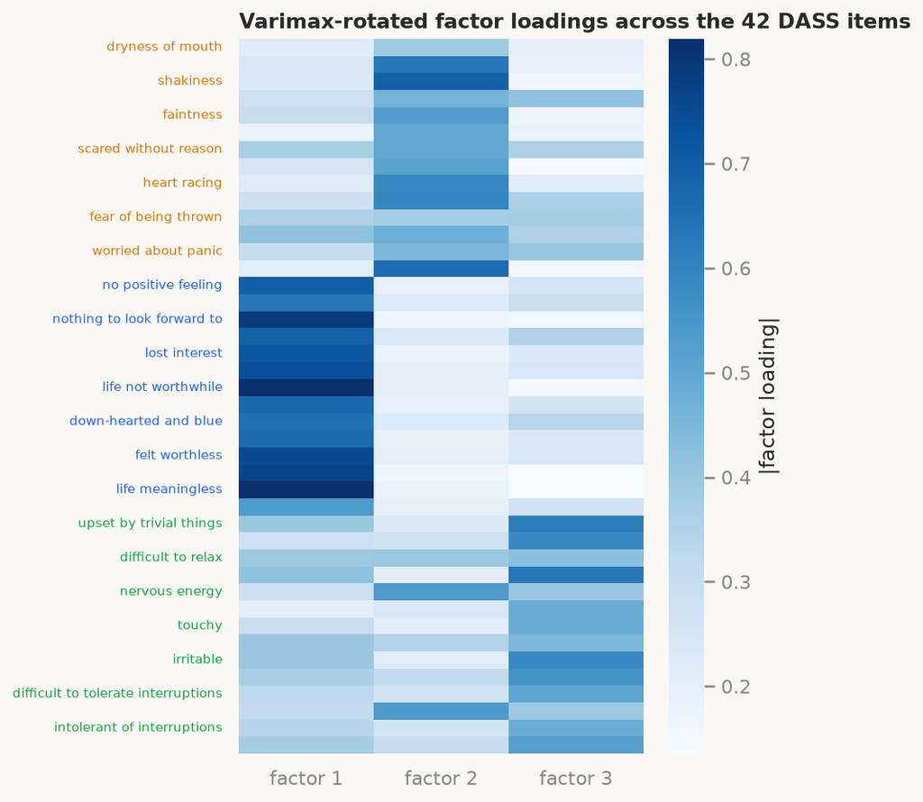

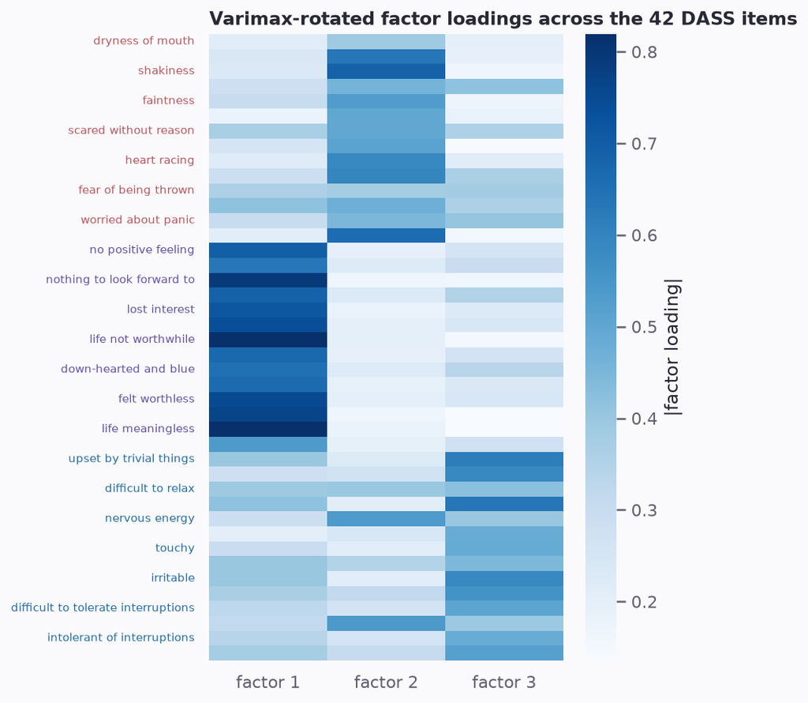

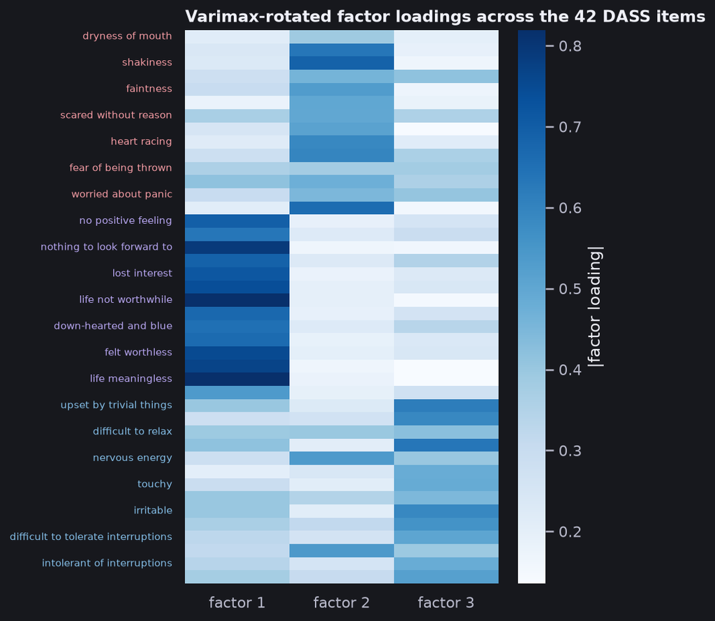

```python
# Draw the results computed above; this cell does not fit the model.
fig, ax = plt.subplots(figsize=(5.2, 7.4))
sns.heatmap(loadings.loc[order_items].abs(), cmap="Blues", cbar_kws={"label": "|factor loading|"}, ax=ax)
for lbl in ax.get_yticklabels():
    lbl.set_color(scale_color[items.set_index("text").scale[lbl.get_text()]]); lbl.set_fontsize(7.5)
ax.set(ylabel=None, title="Varimax-rotated factor loadings across the 42 DASS items")
plt.show()
```

**Music Therapy: 13 Dimensions of Musical Emotion**

How many independent dimensions are needed to capture listeners’ emotional responses across the 28 affective scales in `load_music_emotions`? Below we compute the PCA eigenvalue spectrum across all 28 affective dimensions and inspect a 3-factor varimax rotation:

```python
emo_dims = music_emotions["dimensions"]
standardized_all_emotions = StandardScaler().fit_transform(emotion_ratings[emo_dims])
emotion_pca = PCA().fit(standardized_all_emotions)
cumulative_variance = np.cumsum(emotion_pca.explained_variance_ratio_)
```

Fit three shared factors as a separate descriptive model. Rotating those factors can make their links to individual emotion ratings easier to inspect.

```python
emotion_factors = FactorAnalysis(n_components=3, rotation="varimax", random_state=0).fit(standardized_all_emotions)
emotion_loadings = pd.DataFrame(emotion_factors.components_.T, index=[d.split("/")[0] for d in emo_dims],
                     columns=["Factor 1", "Factor 2", "Factor 3"])

print(f"First 3 components explain {cumulative_variance[2]:.0%} of variance; 13 components explain {cumulative_variance[12]:.0%}")
```

```
First 3 components explain 47% of variance; 13 components explain 84%
```

**Show the figure code**

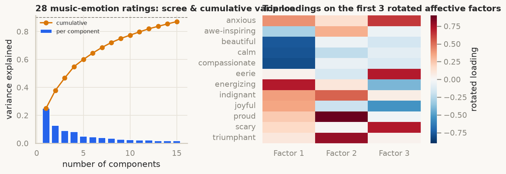

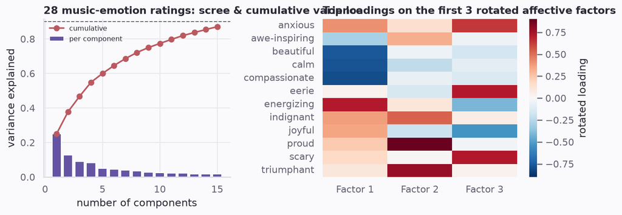

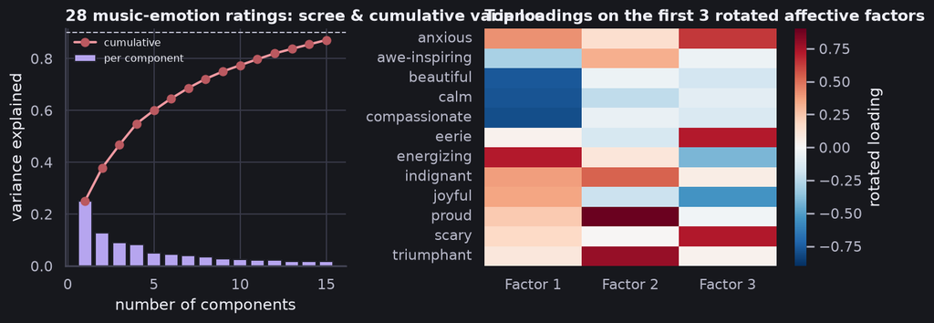

```python
# Draw the results computed above; this cell does not fit the model.
fig, axes = plt.subplots(1, 2, figsize=(9.6, 3.6), gridspec_kw={"width_ratios": [1, 1.3]})
axes[0].bar(range(1, 16), emotion_pca.explained_variance_ratio_[:15], color=C["blue"], label="per component")
axes[0].plot(range(1, 16), cumulative_variance[:15], "o-", color=C["orange"], lw=1.8, label="cumulative")
axes[0].axhline(0.90, ls="--", color=C["muted"], lw=1)
axes[0].set(xlabel="number of components", ylabel="variance explained", title="28 music-emotion ratings: scree & cumulative variance")
axes[0].legend(frameon=False, fontsize=8)

top_idx = np.unique(np.argsort(- np.abs(emotion_factors.components_), axis=1)[:, :4].ravel())
sns.heatmap(emotion_loadings.iloc[top_idx], cmap="RdBu_r", center=0, vmin=-0.9, vmax=0.9, ax=axes[1], cbar_kws={"label": "rotated loading"})
axes[1].set_title("Top loadings on the first 3 rotated affective factors")
plt.tight_layout()
```

Use the printed cumulative variance and the loading matrix to assess this sample. Factor labels require inspection of the loadings; factor order and sign are arbitrary. The dimensionality claim in Cowen et al. (2020) comes from their broader analysis and is not established by this illustrative three-factor model or a PCA variance cutoff.

**Biology: The Shape of a Finch’s Vocabulary**

Standardize the sound measurements, find ten principal components, and locate every call along those new axes. The first two axes provide a compact view of the call repertoire.

```python
standardized_calls = StandardScaler().fit_transform(call_features)
call_pca = PCA(n_components=10).fit(standardized_calls)
call_components = call_pca.transform(standardized_calls)

print(f"10 principal components retain {call_pca.explained_variance_ratio_.sum():.0%} of variance across 101 acoustic features")
```

```
10 principal components retain 83% of variance across 101 acoustic features
```

**Show the figure code**

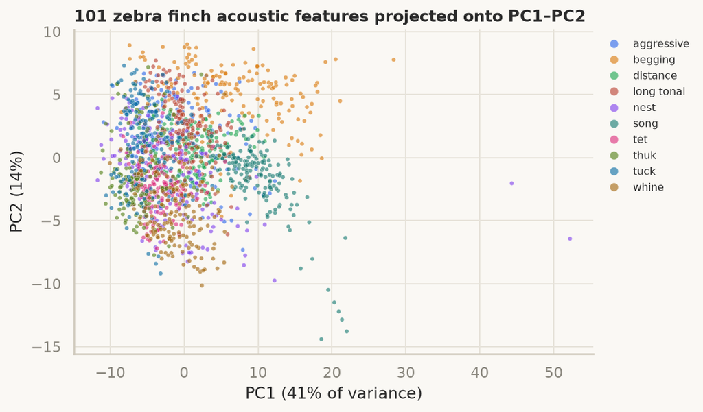

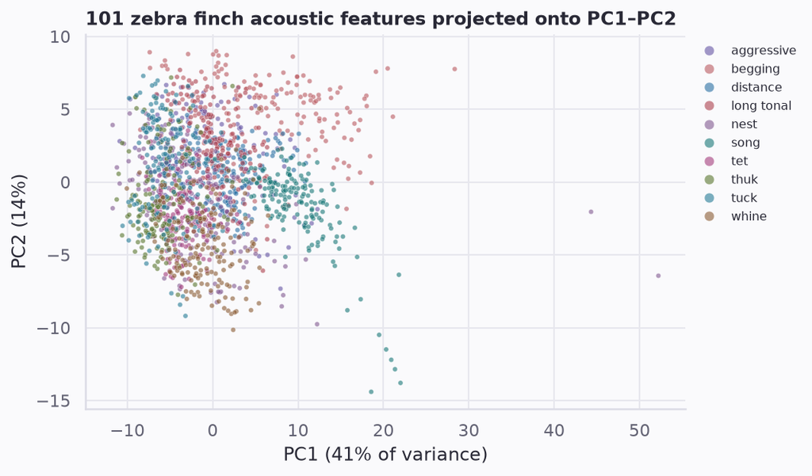

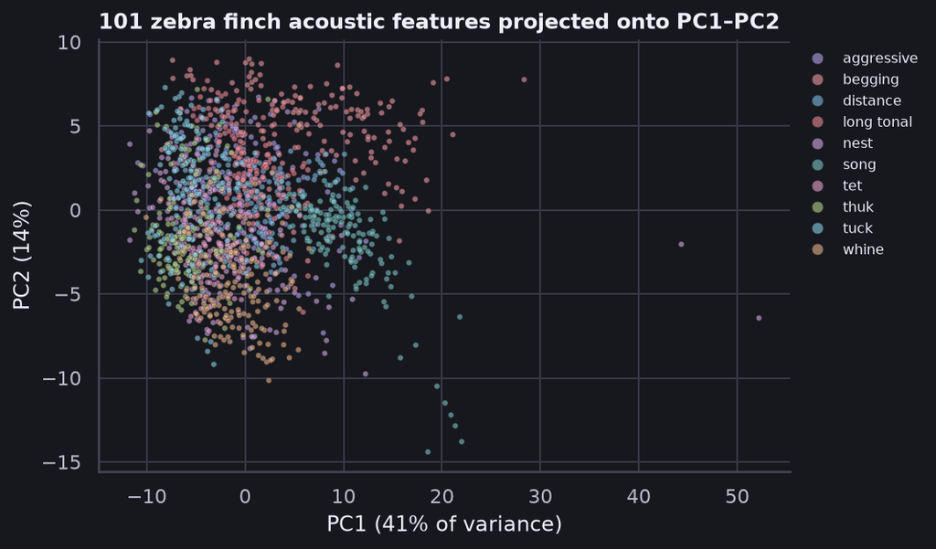

```python
# Draw the results computed above; this cell does not fit the model.
fig, ax = plt.subplots(figsize=(7, 4.4))
sns.scatterplot(x=call_components[:, 0], y=call_components[:, 1], hue=call_metadata.calltype, s=10, alpha=0.6, ax=ax, palette=ml4hl.PALETTE[:len(types)])
ax.set(xlabel=f"PC1 ({call_pca.explained_variance_ratio_[0]:.0%} of variance)",
       ylabel=f"PC2 ({call_pca.explained_variance_ratio_[1]:.0%})", title="101 zebra finch acoustic features projected onto PC1–PC2")
ax.legend(frameon=False, fontsize=8, markerscale=2, bbox_to_anchor=(1, 1))
plt.show()
```

**Show the interactive figure code**

```python
codes = call_metadata.calltype.astype("category").cat.codes.to_numpy()
keep = rng.choice(len(standardized_calls), 220, replace=False)
show("projection", data=dict(X2=call_components[keep, :2] * np.array([1, -1]), Xhigh=standardized_calls[keep], labels=codes[keep]), mode="random")
```

**Going faster**

To visualize curved manifolds in 2D, neighborhood-graph methods such as **uniform manifold approximation and projection (UMAP)** (`pip install umap-learn`, `umap.UMAP().fit_transform(X)`) and **t-distributed stochastic neighbor embedding (t-SNE)** (`sklearn.manifold.TSNE`) emphasize local k-nearest-neighbor topology at the cost of distorting global Euclidean distances between separated clusters. For out-of-core datasets, `IncrementalPCA` fits PCA in streaming mini-batches, and `cuml.accel` accelerates `PCA`, `UMAP`, and `TSNE` on GPU.

# 6 Representational Similarity Analysis: Compare Two Minds

Suppose two systems respond to the same set of $N$ stimuli: a cortical region and a deep neural network, American and Chinese music listeners, or human behavioral judgments and a language model’s embeddings. Their internal measurements have different dimensionalities and units ($d_A \neq d_B$), so individual features cannot be aligned one-to-one. How can we quantify whether the two systems organize the stimuli according to the same geometry?

**Representational similarity analysis** (RSA) compares systems through their second-order **relational geometry**. Within each system, compute the dissimilarity between every pair of stimuli $(i, j)$ to form an $N \times N$ **representational dissimilarity matrix** (RDM). Because both RDMs have identical dimensions ($N \times N$) regardless of the original feature counts $d_A$ and $d_B$, we can extract the $N(N-1)/2$ unique pairs in the upper triangle of each RDM and compute their rank correlation (Spearman’s $\rho$).

## 6.1 Building and Comparing RDMs

**Show the interactive figure code**

```python
show("rdm_builder")
```

Figure 14 displays two $24 \times 24$ RDMs computed from a synthetic 8-feature system $A$ and a 12-feature system $B$ responding to the same 24 stimuli across 4 categories. Light entries mark similar stimulus pairs; dark entries mark dissimilar pairs. The right panel plots the 276 upper-triangle pairs from $\text{RDM}_A$ against $\text{RDM}_B$ and reports their Spearman rank correlation $\rho$:

- **Hover** any matrix cell to highlight the corresponding stimulus pair $(i, j)$ in both RDMs and in the pairwise scatter plot.
- **Permute the stimulus order** (`shuffled`): the visual block structure disappears because rows and columns are re-indexed, but every pair $(i, j)$ retains its values in both matrices, leaving Spearman’s $\rho$ invariant.
- Increase **noise in B** to degrade representational alignment, and click **shuffle test** to build a permutation null distribution by randomly permuting stimulus labels $500$ times.

**Takeaway #8**

To compare two systems with different feature spaces, compare their pairwise representational dissimilarity matrices (RDMs).

## 6.2 Applied Example: Do models judge similarity like people?

The [THINGS](https://things-initiative.org) initiative collected 4.7 million human odd-one-out triplet judgments across 1,854 everyday object concepts. From those behavioral choices, [Hebart et al. (2020)](https://doi.org/10.1038/s41562-020-00951-3) estimated a 66-dimensional embedding (**SPoSE**, sparse positive similarity embedding: a compact set of nonnegative features fitted to similarity judgments) whose axes correspond to interpretable semantic and perceptual dimensions (animacy, edibility, metallic texture, tool use). Below, we use RSA to compare human SPoSE representations against 768-dimensional text embeddings from SigLIP 2:

**Variables in This Example**

`concept_metadata` identifies the shared objects. `human_embeddings` represents human similarity judgments, while `model_embeddings` represents the model’s text features. Rows must refer to the same concept in both arrays.

```python
from ml4hl.data import load_things

things = load_things()
concept_metadata, human_embeddings, model_embeddings = things["meta"], things["spose"].astype(float), things["model"].astype(float)
print(f"{len(concept_metadata)} concepts · human space: {human_embeddings.shape[1]} dims · model space: {model_embeddings.shape[1]} dims ({things['model_name']})")
concept_metadata.category.value_counts().head(8)
```

```
1854 concepts · human space: 66 dims · model space: 768 dims (google/siglip2-base-patch16-224)
```

```
category
other                406
food                 185
animal               177
clothing             108
container            102
electronic device     68
vehicle               64
sports equipment      50
Name: count, dtype: int64
```

We first construct correlation-distance RDMs for a balanced subset of 96 concepts (12 concepts across 8 superordinate categories) using `rsatoolbox`:

```python
import rsatoolbox
from scipy.stats import rankdata

concept_categories = [c for c in concept_metadata.category.value_counts().index if c != "other"][:8]
selected_concepts = pd.concat([concept_metadata[concept_metadata.category == category].head(12) for category in concept_categories])
assert len(selected_concepts) == 12 * len(concept_categories)
assert selected_concepts.index.is_unique
# Use these exact row indices in both systems to preserve concept alignment.
concept_rows = selected_concepts.index.to_numpy()
```

Keep the same concepts in the same order in both systems, then calculate how dissimilar each pair is. This allows comparison even though the two systems use different numbers of features.

```python
# Attach matching concept labels to each system’s feature table.
def rsa_dataset(X, label):
    return rsatoolbox.data.Dataset(X[concept_rows], descriptors={"system": label},
                                   obs_descriptors={"concept": selected_concepts.concept.tolist(), "category": selected_concepts.category.tolist()})

rdm_human = rsatoolbox.rdm.calc_rdm(rsa_dataset(human_embeddings, "human (SPoSE)"), method="correlation")
rdm_model = rsatoolbox.rdm.calc_rdm(rsa_dataset(model_embeddings, "SigLIP 2 text"), method="correlation")

similarity_correlation = rsatoolbox.rdm.compare(rdm_human, rdm_model, method="spearman")[0, 0]
print(f"Spearman ρ between human and model RDMs: {similarity_correlation:.2f}")
```

```
Spearman ρ between human and model RDMs: 0.30
```

**Show the figure code**

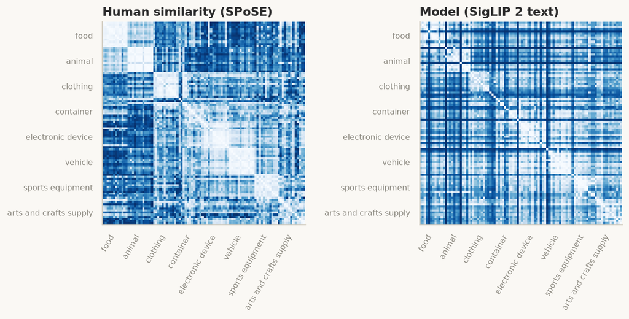

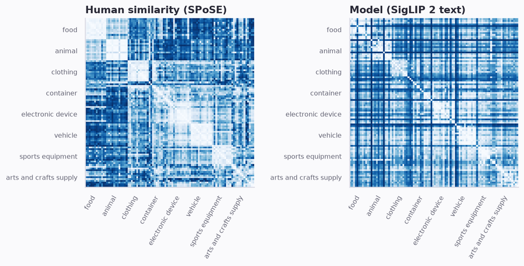

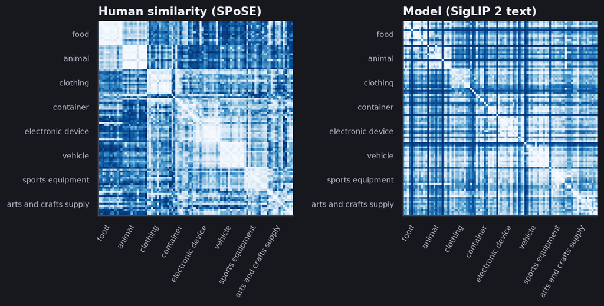

```python
# Draw the results computed above; this cell does not fit the model.
fig, axes = plt.subplots(1, 2, figsize=(9, 4.4))
for ax, rdm, title in zip(axes, [rdm_human, rdm_model], ["Human similarity (SPoSE)", "Model (SigLIP 2 text)"]):
    mat = rdm.get_matrices()[0]
    ranked = rankdata(mat).reshape(mat.shape)   # rank-transform for visual contrast
    ax.imshow(ranked, cmap="Blues", interpolation="nearest")
    ticks = np.arange(6, len(concept_rows), 12)
    ax.set_xticks(ticks, concept_categories, rotation=60, ha="right", fontsize=8); ax.set_yticks(ticks, concept_categories, fontsize=8)
    ax.set_title(title); ax.grid(False)
plt.tight_layout()
```

Inspect the within-category blocks along the diagonal and compare them with between-category pairs in each RDM. Passing a 24-concept subset into `rdm_builder` lets you inspect individual concept pairs directly:

**Show the interactive figure code**

```python
small = concept_metadata[concept_metadata.category.isin(concept_categories[:4])].groupby("category").head(6).sort_values("category")
show("rdm_builder", data=dict(
    names=small.concept.tolist(), groups=small.category.tolist(),
    A=human_embeddings[small.index], B=model_embeddings[small.index],
    labelA="human similarity (SPoSE)", labelB="SigLIP 2 text"))
```

To benchmark the observed $\rho$, we compare it against (1) a **label-permutation null distribution** (1,000 random permutations of the rows and columns of $\text{RDM}_{\text{model}}$) and (2) a binary **categorical model RDM** ($d_{ij} = 0$ if concepts $i, j$ share a category and $1$ otherwise):

**Variables in This Example**

`human_distances` and `model_distances` hold one value for each unique concept pair. `unique_pair_indices` selects those pairs from a square matrix. `shuffled_correlations` records the correlations after breaking the concept correspondence.

```python
from scipy.spatial.distance import pdist, squareform
from scipy.stats import spearmanr, rankdata

human_distances = pdist(human_embeddings[concept_rows], "correlation")
model_distances = pdist(model_embeddings[concept_rows], "correlation")
category_distances = pdist(selected_concepts.category.astype("category").cat.codes.to_numpy()[:, None], lambda u, v: float(u[0] != v[0]))
```

Shuffle the correspondence between concepts in the two systems, keeping each system’s internal distances intact. Repeat this 1,000 times to build a comparison distribution.

```python
model_distance_matrix = squareform(rankdata(model_distances))
# Keep only the upper triangle: each unordered concept pair appears once.
unique_pair_indices = np.triu_indices(len(concept_rows), 1)
human_distance_ranks = rankdata(human_distances)
shuffled_correlations = []
# Shuffle whole concept identities, not individual distance entries.
for _ in range(1000):
    p = rng.permutation(len(concept_rows))
    shuffled_correlations.append(np.corrcoef(human_distance_ranks, model_distance_matrix[np.ix_(p, p)][unique_pair_indices])[0, 1])
shuffled_correlations = np.array(shuffled_correlations)
```

Count how many shuffled correlations meet or exceed the observed correlation. The reported p-value describes this label-shuffling null, not the probability that the two systems think alike.

```python
# Include the observed arrangement so a finite simulation never reports p = 0.
rsa_p = (1 + np.count_nonzero(shuffled_correlations >= similarity_correlation)) / (len(shuffled_correlations) + 1)
print(f"One-sided Monte Carlo permutation p = {rsa_p:.4f} (1,000 permutations; minimum attainable = {1/(len(shuffled_correlations)+1):.4f})")
print(f"categorical RDM vs human: ρ = {spearmanr(category_distances, human_distances)[0]:.2f} · categorical RDM vs SigLIP: ρ = {spearmanr(category_distances, model_distances)[0]:.2f}")
```

```
One-sided Monte Carlo permutation p = 0.0010 (1,000 permutations; minimum attainable = 0.0010)
categorical RDM vs human: ρ = 0.47 · categorical RDM vs SigLIP: ρ = 0.25
```

**Show the figure code**

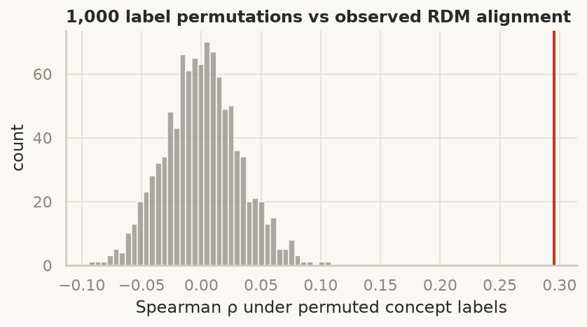

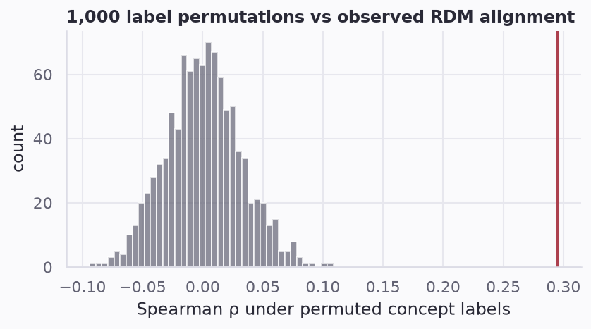

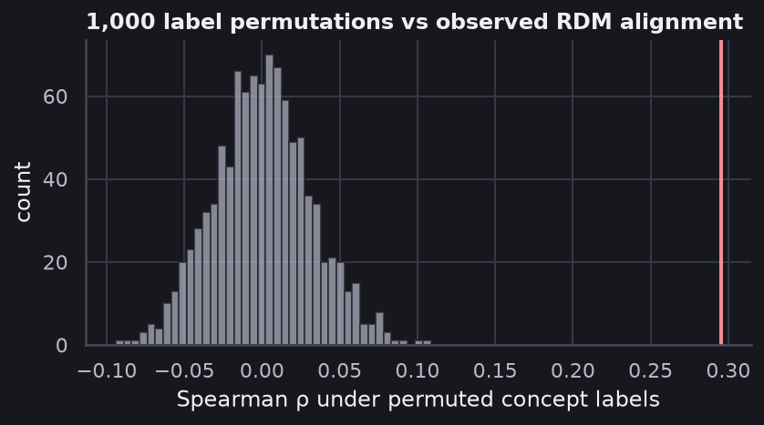

```python
# Draw the results computed above; this cell does not fit the model.
fig, ax = plt.subplots(figsize=(6.5, 3))
ax.hist(shuffled_correlations, bins=40, color=C["muted"], alpha=0.7)
ax.axvline(similarity_correlation, color=C["red"], lw=2)
ax.set(xlabel="Spearman ρ under permuted concept labels", ylabel="count", title="1,000 label permutations vs observed RDM alignment")
plt.show()
```

Finally, we compute the second-order correlation across all $1,854$ concepts ($\binom{1854}{2} = 1,717,731$ unique pairs) directly with `scipy.spatial.distance.pdist`:

```python
full_similarity_correlation = spearmanr(pdist(human_embeddings, "correlation"), pdist(model_embeddings, "correlation"))[0]
print(f"All {len(concept_metadata):,} concepts ({len(concept_metadata) * (len(concept_metadata) - 1) // 2:,} pairs): Spearman ρ = {full_similarity_correlation:.2f}")
```

```
All 1,854 concepts (1,717,731 pairs): Spearman ρ = 0.21
```

Across the full lexicon, including concepts without a single dominant category, the printed rank correlation measures correspondence between the two dissimilarity structures. It is not a fraction of variance explained or evidence of identical representations. This motivates multimodal comparisons against vision and audio-visual foundation models (for a recent, hot-off-the-press example, see [TIPSv2](https://huggingface.co/google/tipsv2-b14)).

# 7 Cross-Validation: Evaluate Generalization

The applied predictive examples report held-out performance; schematic widgets also display training fit and exploratory scores. This section examines why training-set performance is biased, how cross-validation estimates out-of-sample generalization, and how clustered sampling structures cause data leakage when folds are split naively.

## 7.1 Training and Generalization

A model can learn the peculiarities of the examples it has seen instead of a pattern that carries to new examples. The visualization below lets you compare these two outcomes: fit the training dots more closely, then check whether the held-out dots benefit too.

**Show the interactive figure code**

```python
show("overfitting")
```

In Figure 15, filled circles mark **training** observations and hollow rings mark **held-out test** observations drawn from the same data-generating curve. Increase the polynomial degree slider from $1$ to $15$. Increasing polynomial degree can reduce training error while making the fitted curve sensitive to noise. Held-out error may then rise; the best degree varies with the sample, and finite precision and regularization can affect the training curve. A growing gap between training and held-out performance is evidence of **overfitting**. Treat a split used to choose degree as validation data and reserve a separate test set for final evaluation. Click **new sample** repeatedly to observe how high-degree fits fluctuate wildly across samples while low-degree fits remain stable around the true function.

**Takeaway #9**

Training error measures fit to the observed sample. Evaluate generalization on data excluded from fitting and model selection.

## 7.2 Cross-Validation and Group Leakage

Rather than relying on a single train/test split, **$k$-fold cross-validation** partitions the dataset into $k$ folds, approximately equal-sized when constraints permit, fits the model on $k - 1$ folds, evaluates on the held-out fold, and averages test performance across all $k$ rotations.

Random observation-level folds estimate performance on new observations drawn under a similar sampling process. Repeated observations from participants, vocalists, societies, birds, or households can share information. To estimate performance on new sampling units, hold those units out together. Grouped folds do not by themselves establish independence or generalization to every new population.

**Show the interactive figure code**

```python
show("cv_folds")
```

In Figure 16, each column represents one observation colored by its group (e.g., participant or household), and each row represents one cross-validation fold (the legend identifies train and test). In the scatter panel, segments connect each test point to its nearest training neighbor whenever both belong to the same group. Under standard `kfold` or `stratified` splitting, groupmates appear in both train and test sets simultaneously, allowing a nearest-neighbor classifier to match group-specific offsets and substantially overestimate out-of-sample accuracy (solid accuracy line versus the dashed out-of-group baseline).

Switch the scheme to **group** (`GroupKFold`): every group is assigned intact to a single fold, the within-group red links vanish, and the estimate targets unseen-group performance under the simulated sampling process. Its uncertainty and applicability still depend on the sampled groups.

**Takeaway #10**

Split cross-validation folds along the sampling unit you intend to generalize across: by participant, by vocalist, by bird, or by household.

## 7.3 How Sure Are You? Resampling

Any sample statistic or cross-validated score carries sampling uncertainty. **Resampling** methods quantify that uncertainty directly from the empirical sample without assuming parametric formulas:

- **The bootstrap** draws $B$ resamples of size $n$ *with replacement* from each group and recomputes the statistic on every resample; the central 95% gives an approximate percentile **confidence interval**, whose coverage depends on sampling and regularity assumptions. Resample independent sampling units; repeated or clustered observations require a suitable cluster or block bootstrap.
- **A permutation test** asks how surprising an observed difference would be if labels could be exchanged under a specified null hypothesis. Shuffle the labels many times, calculate the difference after each shuffle, and count how often the shuffled result is at least as extreme as the observed one. The Monte Carlo (random-simulation) **$p$-value** is that count plus one, divided by the number of shuffles plus one; the additions keep a finite simulation from reporting an impossible certainty of zero. Only exchange labels in ways allowed by the study design; this value is not the probability that the null hypothesis is true.

Below, we pass age-8 Child Behavior Checklist (CBCL) externalizing scores (parent-reported outward-directed behavior problems) from low versus high teaching-composite groups (`perinatal_attention_groups` from the longitudinal IHDP dataset) directly into the `resampling` widget:

**Show the interactive figure code**

```python
from ml4hl.samples import perinatal_attention_groups

show("resampling", data=perinatal_attention_groups(n_per_group=32))
```

For a comprehensive walkthrough of bootstrap confidence intervals, permutation tests, and cross-validation designs, see the companion tutorial, [Bootstrapping, Permutation, and Cross-Validation](https://colinconwell.com/Tutorials/tutorials/boot-permute-cv/).

## 7.4 Applied Example: Group Leakage in Zebra Finch Vocalizations

To quantify group leakage on real bioacoustic recordings, we evaluate two classifiers on the zebra finch repertoire under both call-level `StratifiedKFold` (which mixes recordings from the same bird across train and test folds) and bird-level `GroupKFold`:

```python
from sklearn.model_selection import StratifiedKFold, permutation_test_score
from sklearn.neighbors import KNeighborsClassifier

leakage_models = {
    "1-nearest neighbor": make_pipeline(StandardScaler(), KNeighborsClassifier(n_neighbors=1)),
    "logistic regression": make_pipeline(StandardScaler(), LogisticRegression(max_iter=3000)),
}
schemes = {"stratified k-fold (calls)": StratifiedKFold(5, shuffle=True, random_state=0),
           "group k-fold (birds)": finch_cv}
```

Run every model with both split schemes and compare held-out accuracy. The input features and labels stay the same; only the grouping rule changes.

```python
leakage_scores = pd.DataFrame([
    dict(model=m, scheme=s, accuracy=cross_val_score(estimator, call_features, call_metadata.calltype, groups=call_metadata.bird, cv=cv, n_jobs=N_JOBS).mean())
    for m, estimator in leakage_models.items() for s, cv in schemes.items()])

leakage_scores.pivot(index="model", columns="scheme", values="accuracy").style.format("{:.0%}")
```

| scheme model | group k-fold (birds) | stratified k-fold (calls) |
| --- | --- | --- |
| 1-nearest neighbor | 66% | 89% |
| logistic regression | 72% | 83% |

**Show the figure code**

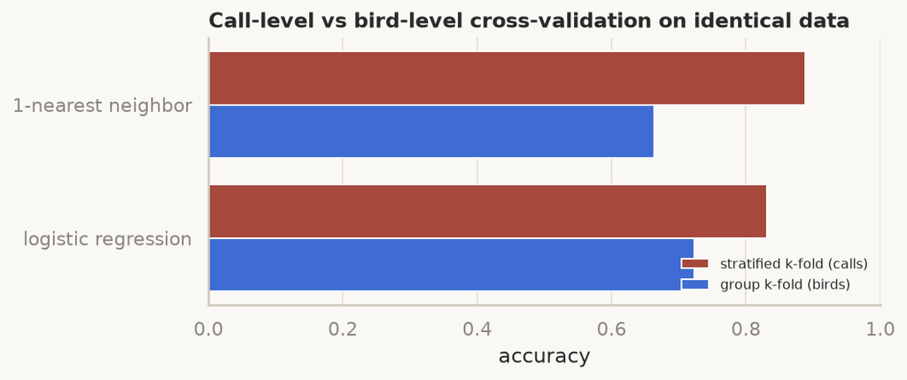

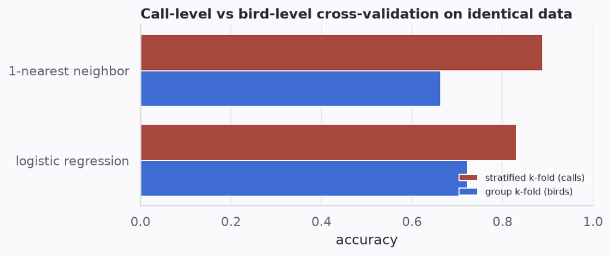

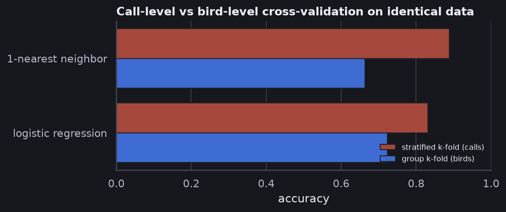

```python
# Draw the results computed above; this cell does not fit the model.
fig, ax = plt.subplots(figsize=(7, 2.8))
sns.barplot(leakage_scores, y="model", x="accuracy", hue="scheme", palette=[C["red"], C["blue"]], ax=ax)
ax.set(xlim=(0, 1), ylabel=None, title="Call-level vs bird-level cross-validation on identical data")
ax.legend(frameon=False, fontsize=8, loc="lower right")
plt.show()
```

Compare the call-level and bird-level scores above. Bird identity is a plausible source of dependence, which we examine by predicting individual identity from acoustic features:

```python
bird_accuracy = cross_val_score(leakage_models["logistic regression"], call_features, call_metadata.bird,
                           cv=StratifiedKFold(5, shuffle=True, random_state=0), n_jobs=N_JOBS).mean()
print(f"Individual bird identification from a single call: {bird_accuracy:.0%} accuracy (uniform-guess reference = {1 / call_metadata.bird.nunique():.1%})")
```

```
Individual bird identification from a single call: 64% accuracy (uniform-guess reference = 2.4%)
```

Differences between the two split schemes are consistent with sensitivity to bird-specific structure, but the comparison alone does not identify its causal contribution. The permutation test below shuffles call-type labels within each bird while keeping bird-level folds. This tests a conditional null that preserves each bird’s label composition and assumes calls are exchangeable within bird; recording-session dependence can violate that assumption.

```python
# Shuffle call types within birds while continuing to hold whole birds out.
score, shuffled_accuracies, permutation_pvalue = permutation_test_score(
    leakage_models["logistic regression"], call_features, call_metadata.calltype, groups=call_metadata.bird,
    cv=finch_cv, n_permutations=100, n_jobs=N_JOBS, random_state=0)

print(f"Observed held-out accuracy: {score:.0%} · highest shuffled-label accuracy: {shuffled_accuracies.max():.0%} · p = {permutation_pvalue:.3f} (100 permutations)")
```

```
Observed held-out accuracy: 72% · highest shuffled-label accuracy: 24% · p = 0.010 (100 permutations)
```

**Show the figure code**

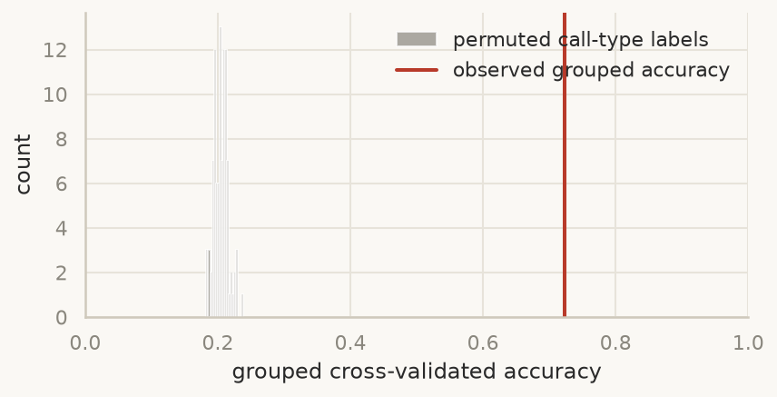

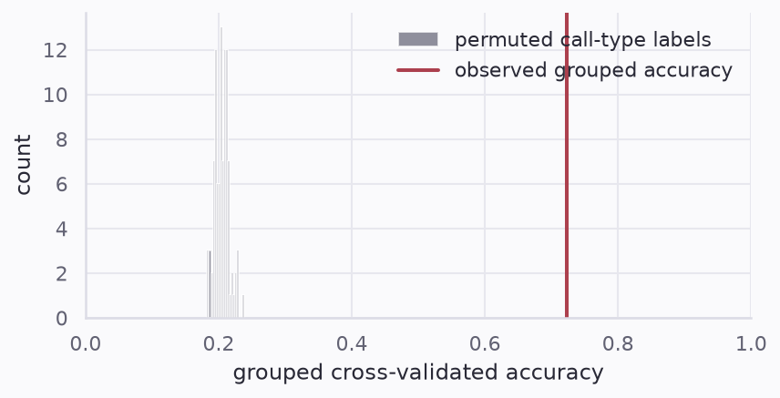

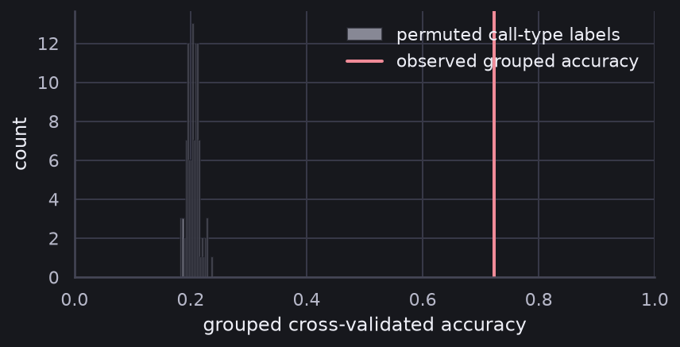

```python
# Draw the results computed above; this cell does not fit the model.
fig, ax = plt.subplots(figsize=(6.5, 3))
ax.hist(shuffled_accuracies, bins=20, color=C["muted"], alpha=0.7, label="permuted call-type labels")
ax.axvline(score, color=C["red"], lw=2, label="observed grouped accuracy")
ax.set(xlabel="grouped cross-validated accuracy", ylabel="count", xlim=(0, 1))
ax.legend(frameon=False)
plt.show()
```

**Going faster**

`cross_val_score`, `cross_val_predict`, and `permutation_test_score` accept `n_jobs=-1` to parallelize folds across all CPU cores. For hyperparameter tuning across large grids, `HalvingGridSearchCV` allocates compute via successive halving, and [Optuna](https://optuna.org) performs Bayesian hyperparameter optimization.

# 8 Wrapping Up

## 8.1 The Ten Takeaways

1. Learning uses past data (previous experience) to construct and update models that predict unseen data (future experiences).
2. Many learning methods optimize an objective, but with incomplete information they need not find its global minimum. Even that minimum need not be the pattern that best predicts data not yet seen.
3. A model is a parameterized family of functions. Training adjusts the parameters to minimize error.
4. Spline regression combines basis functions to model curvature. A one-dimensional ReLU network represents a continuous piecewise-linear function whose breakpoints can be learned.
5. A classifier learns the boundaries of categorical groupings based on a set of features that differentiate the exemplars of those categories to greater or lesser extents.
6. Clustering partitions data according to a geometric assumption about their proximity or distance (touching neighborhoods, spherical centers, or hierarchical linkage).
7. High-dimensional measurements often lie near a lower-dimensional subspace. Dimensionality reduction isolates the directions that capture the dominant variance of the higher-dimensional space.
8. To compare two systems with different feature spaces, compare their pairwise representational dissimilarity matrices (RDMs).
9. Training error measures fit to the observed sample. Evaluate generalization on data excluded from fitting and model selection.
10. Split cross-validation folds along the sampling unit you intend to generalize across: by participant, by vocalist, by bird, or by household.

## 8.2 The Whole Toolkit on One Page

The following template applies to supervised prediction with grouped cross-validation:

```python
from sklearn.pipeline import make_pipeline
from sklearn.preprocessing import StandardScaler
from sklearn.linear_model import LogisticRegression
from sklearn.model_selection import GroupKFold, cross_val_score

# X = measured features, y = category labels, participant_ids = sampling-unit labels.
model = make_pipeline(StandardScaler(), LogisticRegression(max_iter=1000))     # 1. specify pipeline
cv = GroupKFold(5, shuffle=True, random_state=0)                              # 2. split by sampling unit
scores = cross_val_score(model, X, y, groups=participant_ids, cv=cv)          # 3. fit and evaluate per fold
print(f"Mean held-out classification accuracy across {len(scores)} group folds: {scores.mean():.1%}")                                                          # 4. report held-out score
```

| Goal | Start with | Upgrade to |
| --- | --- | --- |
| predict a number (linear or curved) | `LinearRegression`, `RidgeCV`, `SplineTransformer` | `HistGradientBoostingRegressor` |
| predict a category | `LogisticRegression` | `HistGradientBoostingClassifier`, XGBoost, LightGBM |
| discover groups | `KMeans`, `AgglomerativeClustering` | `GaussianMixture` (overlapping, elliptical groups) |
| reduce dimensions | `PCA`, `FactorAnalysis` | UMAP, t-SNE (neighborhood visualization) |
| compare representations | `scipy.spatial.distance.pdist` + `spearmanr` | `rsatoolbox` |
| evaluate generalization & uncertainty | `cross_val_score` with `GroupKFold` | `permutation_test_score`, bootstrap confidence intervals |

**Going faster: summary**

**Accelerating the same API.** Pass `n_jobs=-1` to parallelize cross-validation and resampling across CPU cores. On an NVIDIA GPU (including Google Colab’s GPU runtime), `%load_ext cuml.accel` dispatches supported `scikit-learn` estimators to the GPU without code modifications, and `import sklearnex; sklearnex.patch_sklearn()` accelerates CPU execution on Intel hardware. For large tabular workflows, [Polars](https://pola.rs) and [Ibis](https://ibis-project.org) provide high-throughput dataframe engines.

## 8.3 Glossary

**Bottleneck**

A narrow intermediate layer in an autoencoder that forces the network to compress high-dimensional inputs into a low-dimensional latent code.

**Classification**

Supervised prediction of a discrete categorical label.

**Cross-validation**

Partitioning data into $k$ folds so every observation is evaluated once while held out from training.

**Feature**

A single measured variable or coordinate describing an observation (e.g., an acoustic parameter, survey indicator, or embedding dimension).

**Gradient descent**

Iterative optimization that updates model parameters in the direction of steepest decrease of the loss function.

**Group k-fold**

Cross-validation scheme that keeps all observations from the same sampling unit (participant, vocalist, bird, household) within the same fold.

**Learning rate**

Scalar step size multiplying the gradient during parameter updates.

**Overfitting**

Fitting sample-specific noise in the training data, reducing accuracy on unseen test observations.

**Principal component**

Orthogonal axis capturing the maximum remaining variance in a dataset.

**RDM**

Representational dissimilarity matrix: an $N \times N$ symmetric matrix recording pairwise distances between $N$ stimuli within a system.

**Regression**

Supervised prediction of a continuous numerical outcome.

**ReLU (rectified linear unit)**

Piecewise-linear hinge activation $\max(0, z)$ that stays zero below a knot threshold and rises linearly above it.

**Self-supervised learning**

Training a model to predict part of the data from itself (such as reconstructing inputs through an autoencoder bottleneck) without external labels.

**Spline / knot**

A piecewise polynomial curve joined smoothly at landmark points (**knots**) along the input axis.

**Supervised / unsupervised**

Learning with (`supervised`) or without (`unsupervised`) an explicit target variable $y$.

**Weights**

Learnable parameters inside a model adjusted during training to minimize loss.

## 8.4 Data Sources

All datasets used in this tutorial are publicly available. Please cite the primary publications when using them in research.

| Dataset | Domain | Primary source |
| --- | --- | --- |
| World Bank Living Standards Measurement Study (LSMS) household health & expenditure (`load_household_survey`) | anthropology, health economics | World Bank Living Standards Measurement Study; Cameron & Trivedi (2005) |
| Dollar Street household photos & incomes (`load_dollar_street`) | anthropology | [Gapminder Dollar Street](https://www.gapminder.org/dollar-street) (Creative Commons Attribution, CC BY 4.0), via [`iamshnoo/dollarstreet`](https://huggingface.co/datasets/iamshnoo/dollarstreet) |
| Stanford Wordbank MacArthur–Bates Communicative Development Inventories (MB-CDI) vocabulary (`load_wordbank`) | child development, language acquisition | Frank et al. (2017, 2021), [Wordbank](https://wordbank.stanford.edu) MacArthur-Bates CDI repository |
| IHDP perinatal risk, language, reading & attention (`load_perinatal_dev`) | developmental & clinical psychology | Brooks-Gunn et al. (1992); Infant Health and Development Program longitudinal cohort |
| DASS-42 symptom inventory (`load_dass`) | clinical psychology | Lovibond & Lovibond (1995); [Open-Source Psychometrics Project](https://openpsychometrics.org/_rawdata/) |
| The Music Lab Natural History of Song (NHS) & infant-directed vocalizations (`load_musiclab`) | music therapy, child dev, anthropology | Mehr et al. (2019), *Science*; Hilton et al. (2022), *Nature Human Behaviour* ([The Music Lab](https://themusiclab.org)) |
| 13-Dimensions of Music Emotion (`load_music_emotions`) | music therapy, affective science | Cowen et al. (2020), *Proceedings of the National Academy of Sciences (PNAS)*, via [`baobaoh/13-dimensions-music-emotions`](https://huggingface.co/datasets/baobaoh/13-dimensions-music-emotions) |
| THINGS concepts & SPoSE human similarity (`load_things`) | cognitive science, perception | Hebart et al. (2020), *Nature Human Behaviour* ([THINGS initiative](https://things-initiative.org)) |
| Zebra finch vocal repertoire (`load_finch`) | organismal & perceptual biology | Elie & Theunissen (2016), *Animal Cognition*, via [`cgeorgiaw/animal-sounds`](https://huggingface.co/datasets/cgeorgiaw/animal-sounds) |
| Wisconsin breast biopsy & PneumoniaMNIST | clinical medicine | [University of California, Irvine (UCI) Machine Learning Repository](https://archive.ics.uci.edu/dataset/17); Yang et al. (2023), *Scientific Data* ([MedMNIST v2](https://medmnist.com)) |

Image and text embeddings were computed with [SigLIP 2](https://huggingface.co/google/siglip2-base-patch16-224). Precomputed artifacts and the `ml4hl` package are hosted on the [`colinconwell/ml4hl`](https://huggingface.co/datasets/colinconwell/ml4hl) Hugging Face dataset repository and can be rebuilt from source via `scripts/build_artifacts.py`.